# Stats 406 Lab 1 (From Fall 2016)

Byoungwook Jang

September 15, 2017

## Lab info

- Lab section: Friday, 10:00 am - 11:30 am
- Office hours: (Science Learning Center, Chemistry building, attend any)
  - Thursday: 10:00 am - 12:00 pm

Face to face conversation is prefered to email conversations.

## Getting started

```r
# get working directory
getwd()
```

```
## [1] "C:/Users/Wookie/Google Drive/teaching/stats406_f17_labs/lab1"
```

```r
# set appropriate working directory (YOUR OWN DIRECTORY)
setwd("C:/Users/Wookie/Google Drive/teaching/stats406/lab1")
# Looking around, list all files under this directory
list.files()
```

```
## [1] "lab1.R"            "lab1.Rout"         "Stats406Lab1.docx"
## [4] "Stats406Lab1.html" "Stats406Lab1.Rmd"
```

## Data types

There are 6 types of basic data types in R: Logical, Numeric, Integer, Complex, Character, Raw

```r
v = TRUE
print(class(v))
```

```
## [1] "logical"
```

```r
v = 23.5
print(class(v))
```

```
## [1] "numeric"
```

```r
v = 2L
print(class(v))
```

```
## [1] "integer"
```

```r
v = 2+5i
print(class(v))
```

```
## [1] "complex"
```

```r
v = "TRUE"
print(class(v))
```

```
## [1] "character"
```

```r
v = charToRaw("Hello")
print(class(v))
```

```
## [1] "raw"
```

## Vectors and Lists

Vectors contains objects of the *same* type. List doesn’t require members to be of the same type.

### Vectors

```r
# initialize a vector (concatenation)
vector1 = c(1,'A',T,2.3)
# print a vector (works inside functions)
print(vector1)
```

```
## [1] "1"    "A"    "TRUE" "2.3"
```

```r
# another way to display a variable (doesn't work inside functions)
vector1
```

```
## [1] "1"    "A"    "TRUE" "2.3"
```

```r
# another way to initialize a vector
x = 1:10
# yet another way to initialize a vector
x = seq(from = 1, to = 10, by = 1);x
```

```
##  [1]  1  2  3  4  5  6  7  8  9 10
```

```r
# you can leave out the paramenter names as long as the orders are correct
x = seq(1,10,1);x
```

```
##  [1]  1  2  3  4  5  6  7  8  9 10
```

```r
# initialize a variable using existing ones
y = x^2
# Notice that you don't have to write a loop to define y
# R is 'vector-friendly'
# In fact you should AVOID writting loops in R unless necessary
print(y)
```

```
##  [1]   1   4   9  16  25  36  49  64  81 100
```

### Lists

```r
# Create a list.
list1 = list(c(2,5,3),21.3,sin)
# Now things inside list1 do NOT get converted to the same type!
print(list1)
```

```
## [[1]]
## [1] 2 5 3
##
## [[2]]
## [1] 21.3
##
## [[3]]
## function (x)  .Primitive("sin")
```

### Subsetting a vector / list

```r
# You can ``access'' any elements of a vector / list by providing its index inside the [ ]
vector1[1]
```

```
## [1] "1"
```

```r
# Or by providing a vector of indices
vector1[1:3]
```

```
## [1] "1"    "A"    "TRUE"
```

```r
# Or by providing a vector of Logicals
index = c(T,F,F,T)
vector1[index]
```

```
## [1] "1"   "2.3"
```

#### Quiz: what happens if the length of the Logical index and the vector disagrees?

```r
# vector1[c(T,F,F)]
```

Subsetting a list is **tricky**!

```r
# Subsetting a list with [ ], and you still get a list!
list1[1]
```

```
## [[1]]
## [1] 2 5 3
```

```r
class(list1[1])
```

```
## [1] "list"
```

```r
# To extract the vector, use double [[ ]]
list1[[1]]
```

```
## [1] 2 5 3
```

```r
class(list1[[1]])
```

```
## [1] "numeric"
```

Provocative imagery by [Hadley Wickham](https://twitter.com/hadleywickham/status/643381054758363136):

[figure not shown]

Rlist

## Matrices

Think of them as ``2-D vectors’’.

### Creating a matrix

```r
M = matrix( c(4,2,6,3,7,1), nrow = 2, ncol = 3, byrow = TRUE)
print(M)
```

```
##      [,1] [,2] [,3]
## [1,]    4    2    6
## [2,]    3    7    1
```

```r
# Matrix transpose
t(M)
```

```
##      [,1] [,2]
## [1,]    4    3
## [2,]    2    7
## [3,]    6    1
```

### Naming the columns and rows (always good to have meaningful names)

```r
colnames(M) = c('col1','col2','col3')
rownames(M) = c('row1','row2')
M
```

```
##      col1 col2 col3
## row1    4    2    6
## row2    3    7    1
```

#### Quiz: what happens if the length of the content and the matrix size disagrees?

```r
# M = matrix(1:5, nrow = 2, ncol = 3)
# print(M)
```

Subsetting of a matrix is siimlar to that of a vector, except you need to provide two indices for the two dimensions:

```r
M[2,c(1,3)]
```

```
## col1 col3
##    3    1
```

### Matrix mutiplication

Dimensions must agree! Vectors are treated by default as column vectors.

```r
# with a vector
M%*%c(1,2,3)
```

```
##      [,1]
## row1   26
## row2   20
```

```r
# with another matrix
M%*%t(M)
```

```
##      row1 row2
## row1   56   32
## row2   32   59
```

#### Quiz: what happens if the orientation is misaligned for the vector?

```r
# M%*%t(c(1,2,3))
# What about this?
# t(c(1,2))%*%M
```

## factors

Roughly speaking, storage-wise, an integer array with labels.

Factors are treated differently from intergers when being operated on. More on this later in the course.

```r
# NA does not count as a factor
factor1 = factor(c('apple','orange','apple','apple','orange','pear',NA,'orange'))
# coercion to numerical values produces integer values
as.numeric(factor1)
```

```
## [1]  1  2  1  1  2  3 NA  2
```

```r
# read the factor levels
levels(factor1)
```

```
## [1] "apple"  "orange" "pear"
```

```r
# relabel the levels
levels(factor1) = c("cup","bowl","plate")
# look at the factor again
factor1
```

```
## [1] cup   bowl  cup   cup   bowl  plate <NA>  bowl
## Levels: cup bowl plate
```

## Dataframes

Data frame is an extension to matrices, allowing columns to take different types.

```r
col1 = (1:5)/10; col2 = letters[1:5]; col3 = round(sin(1:5),3);
```

Numerical objects are converted to characters when concatenating A1 to A3, same as when you create a vector of mixed data types.

```r
A = cbind(col1 , col2 , col3) # cbind for 'column bind'
print(A)
```

```
##      col1  col2 col3
## [1,] "0.1" "a"  "0.841"
## [2,] "0.2" "b"  "0.909"
## [3,] "0.3" "c"  "0.141"
## [4,] "0.4" "d"  "-0.757"
## [5,] "0.5" "e"  "-0.959"
```

Data frames keep numerical variables numerical, and convert characters to factors.

```r
dataframe1 = data.frame(col1 , col2 , col3)
dataframe1
```

```
##   col1 col2   col3
## 1  0.1    a  0.841
## 2  0.2    b  0.909
## 3  0.3    c  0.141
## 4  0.4    d -0.757
## 5  0.5    e -0.959
```

Viewing dataframe summaries

```r
summary(dataframe1)
```

```
##       col1     col2       col3
##  Min.   :0.1   a:1   Min.   :-0.959
##  1st Qu.:0.2   b:1   1st Qu.:-0.757
##  Median :0.3   c:1   Median : 0.141
##  Mean   :0.3   d:1   Mean   : 0.035
##  3rd Qu.:0.4   e:1   3rd Qu.: 0.841
##  Max.   :0.5         Max.   : 0.909
```

## [, [[, $, and subset()

It’s nice to subset your function through indexing, but what if you want more? Let’s start with the basics

### Single Bracket

```r
mydata = iris
colnames(iris)
```

```
## [1] "Sepal.Length" "Sepal.Width"  "Petal.Length" "Petal.Width"
## [5] "Species"
```

```r
myvars = c('Sepal.Length', 'Species')
newdata = mydata[myvars]
head(newdata)
```

```
##   Sepal.Length Species
## 1          5.1  setosa
## 2          4.9  setosa
## 3          4.7  setosa
## 4          4.6  setosa
## 5          5.0  setosa
## 6          5.4  setosa
```

```r
# Grabbing columns 1, 3, 4, 5
head(iris[c(1,3:5)])
```

```
##   Sepal.Length Petal.Length Petal.Width Species
## 1          5.1          1.4         0.2  setosa
## 2          4.9          1.4         0.2  setosa
## 3          4.7          1.3         0.2  setosa
## 4          4.6          1.5         0.2  setosa
## 5          5.0          1.4         0.2  setosa
## 6          5.4          1.7         0.4  setosa
```

```r
# Grabbing the 3rd~5th columsn from the first row
head(iris[1,3:5])
```

```
##   Petal.Length Petal.Width Species
## 1          1.4         0.2  setosa
```

```r
# Remove the 1st and 4th column
head(iris[,-c(1, 4)])
```

```
##   Sepal.Width Petal.Length Species
## 1         3.5          1.4  setosa
## 2         3.0          1.4  setosa
## 3         3.2          1.3  setosa
## 4         3.1          1.5  setosa
## 5         3.6          1.4  setosa
## 6         3.9          1.7  setosa
```

```r
# Look at the first 5 observations
head(iris[1:5,])
```

```
##   Sepal.Length Sepal.Width Petal.Length Petal.Width Species
## 1          5.1         3.5          1.4         0.2  setosa
## 2          4.9         3.0          1.4         0.2  setosa
## 3          4.7         3.2          1.3         0.2  setosa
## 4          4.6         3.1          1.5         0.2  setosa
## 5          5.0         3.6          1.4         0.2  setosa
```

### Double Bracket

```r
# Basic example of double bracket
head(iris[[1]])
```

```
## [1] 5.1 4.9 4.7 4.6 5.0 5.4
```

```r
iris[[1]][2]
```

```
## [1] 4.9
```

```r
# Let's play with list now
my_list = list(lower=letters[1:4], upper=letters[-1:-20])
my_list[['lower']][1]
```

```
## [1] "a"
```

```r
my_list['lower'][1]
```

```
## $lower
## [1] "a" "b" "c" "d"
```

The last example shows that the double brackets are useful to referene elements within a list that has a list.

### which and subset

```r
# Look at Setosa iris that has Sepal Length larger than 5
newdata = iris[which(iris$Species=='setosa' & iris$Sepal.Length > 5.0),]
head(newdata)
```

```
##    Sepal.Length Sepal.Width Petal.Length Petal.Width Species
## 1           5.1         3.5          1.4         0.2  setosa
## 6           5.4         3.9          1.7         0.4  setosa
## 11          5.4         3.7          1.5         0.2  setosa
## 15          5.8         4.0          1.2         0.2  setosa
## 16          5.7         4.4          1.5         0.4  setosa
## 17          5.4         3.9          1.3         0.4  setosa
```

```r
# Look at examples that have seplan length larer than 5.5 or smaller than 5.0. We are only interested in Species and Petal.Width
newdata = subset(iris, Sepal.Length >= 5.5 | Sepal.Length < 5.0,
    select=c(Species, Petal.Width))
head(newdata)
```

```
##    Species Petal.Width
## 2   setosa         0.2
## 3   setosa         0.2
## 4   setosa         0.2
## 7   setosa         0.3
## 9   setosa         0.2
## 10  setosa         0.1
```

Note the difference,

https://www.r-bloggers.com/r-accessors-explained/

## Basic plotting

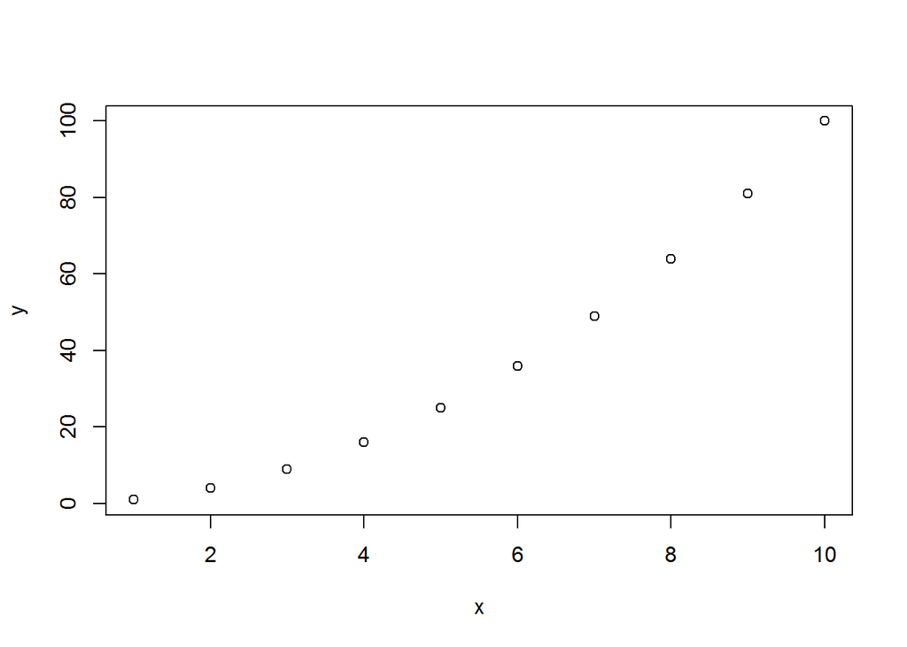

```r
# plot a series against another
plot(x,y)
```

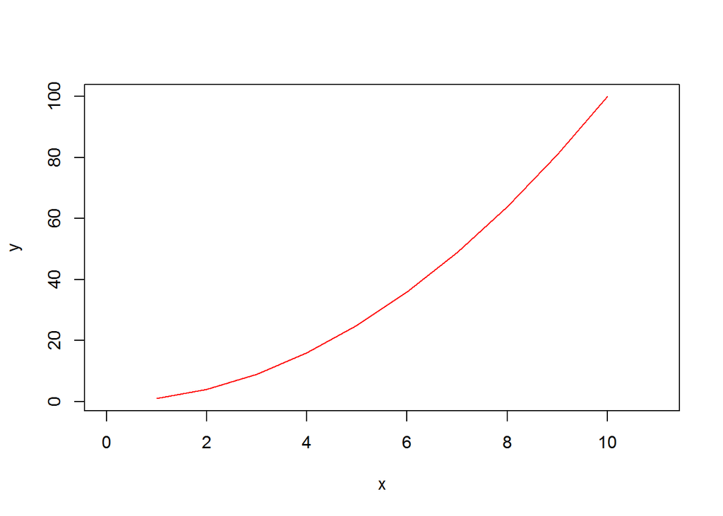

```r
# connecting the dots, add colors, plotting ranges
plot(x,y,type = 'l',col = 'red', xlim = c(0,11))
```

## Look for variables in environment

```r
# list variables in the environment
ls()
```

```
##  [1] "A"          "col1"       "col2"       "col3"       "dataframe1"
##  [6] "factor1"    "index"      "list1"      "M"          "my_list"
## [11] "mydata"     "myvars"     "newdata"    "v"          "vector1"
## [16] "x"          "y"
```

```r
# remove a variable from the environment
rm(list='vector1')
# Now 'vector1' is gone
ls()
```

```
##  [1] "A"          "col1"       "col2"       "col3"       "dataframe1"
##  [6] "factor1"    "index"      "list1"      "M"          "my_list"
## [11] "mydata"     "myvars"     "newdata"    "v"          "x"
## [16] "y"
```

```r
## still remember what list.files() does?
```

## Functions

### How to use an existing function from package

```r
# look for manual for a function
?rm
```

```
## starting httpd help server ... done
```

```r
# fuzzy search
??remove
```

I find Google search more helpful than ``??’’.

### How to define a new function

```r
# use 'function' function
f = function(x){
  x^2-2*x+1
}
# last line is returned, you can also use 'return' for clarity
f = function(x){
  return (x^2-2*x+1)
}
# Now apply it
f(x) # works on numericals
```

```
##  [1]  0  1  4  9 16 25 36 49 64 81
```

```r
# incompatible operation for strings
# f('test')
```

## Extras

- It is always good to keep in mind that computers are finite machines.
- They are only approxiamtely accurate.
- Your algorithm matters.

E.g.

```r
options(digits = 22)
sum(1/1:500000)
```

```
## [1] 13.699580042305527
```

```r
sum(1/500000:1)
```

```
## [1] 13.699580042305529
```

Results are close (for all practical purposes), but bot identical.

## Advanced

[Advanced R](http://adv-r.had.co.nz/) is a good reference if you are into the inner workings of R.

## Q&A

My experience has been that study/research as a community is most effective.

I will post questions here for the benefit of all.

Hope we can learn together.

Email me any suggestions.

```r
x = 1:11
mean(x = x)
```

```
## [1] 6
```

```r
x
```

```
##  [1]  1  2  3  4  5  6  7  8  9 10 11
```

```r
mean(x = 2:12)
```

```
## [1] 7
```

```r
x
```

```
##  [1]  1  2  3  4  5  6  7  8  9 10 11
```

```r
mean(x = 2:12)
```

```
## [1] 7
```

```r
x
```

```
##  [1]  1  2  3  4  5  6  7  8  9 10 11
```

Now what if there are valiables of the same name in further higher environments?

```r
x = 1:11

f1 = function(x){
  mean(x = 2:12)
}

f2 = function(x){
  mean(x = 2:12)
}


f3 = function(x){
  mean(x <= 2:12)
}


f1(x)
```

```
## [1] 7
```

```r
x
```

```
##  [1]  1  2  3  4  5  6  7  8  9 10 11
```

```r
f2(x)
```

```
## [1] 7
```

```r
x
```

```
##  [1]  1  2  3  4  5  6  7  8  9 10 11
```

```r
f3(x)
```

```
## [1] 1
```

```r
x
```

```
##  [1]  1  2  3  4  5  6  7  8  9 10 11
```

## Exercise

#### 1: Create a dataframe or list that contains a Gaussian vector length of 1000 and a binomial vector length of 500

#### 2: In the Iris dataset, subset the data to get versicolor iris that have petal length greater than 1.5